# Introduction

## Research direction

Our research aims to find which factors contribute most to shopping behavior. Nowadays, online shopping become one of the most important parts of the business world. It is necessary to grasp the user’s buying habits and predict their shopping intention. Using these analysis results and prediction to improve shopping websites and applications can improve the sales and profit of these companies.

## Rational

These data on users’ activities and shopping behavior have some relationships. And these relationships can be used to build a prediction model to predict users’ intentions. In that case, online shopping websites can improve their design and push more exact commodities and repo to get higher sales and profit. Meanwhile, customers will have a better shopping experience. Moreover, this analysis is a good reference for a merchant to improve their service and product. Shopping websites and applications also can refer to this model for their marketing strategy. Therefore, this research is meaningful and beneficial to many parties.

## Online Shoppers Purchasing Intention Dataset

### The dataset is about customers’ scanning time, exiting rate, browsing pages, and other information which is relevant to their shopping intention. The dataset is highly consistent with our study. It includes almost every element we’d like to analyze.

"Administrative", "Administrative Duration", "Informational", "Informational Duration", "Product Related" and "Product Related Duration" represent the number of different types of pages visited by the visitor in that session and total time spent in each of these page categories. The values of these features are derived from the URL information of the pages visited by the user and updated in real time when a user takes an action, e.g. moving from one page to another.

"Bounce Rate", "Exit Rate" and "Page Value" features represent the metrics measured by "Google Analytics" for each page in the e-commerce site. The value of "Bounce Rate" feature for a web page refers to the percentage of visitors who enter the site from that page and then leave ("bounce") without triggering any other requests to the analytics server during that session. " The value of "Exit Rate" feature for a specific web page is calculated as for all pageviews to the page, the percentage that were the last in the session. The "Page Value" feature represents the average value for a web page that a user visited before completing an e-commerce transaction. "

"Special Day" feature indicates the closeness of the site visiting time to a specific special day (e.g. Mother’s Day, Valentine's Day) in which the sessions are more likely to be finalized with transaction. The value of this attribute is determined by considering the dynamics of e-commerce such as the duration between the order date and delivery date. For example, for Valentina’s day, this value takes a nonzero value between February 2 and February 12, zero before and after this date unless it is close to another special day, and its maximum value of 1 on February 8.

The dataset also includes operating system, browser, region, traffic type, visitor type as returning or new visitor, a Boolean value indicating whether the date of the visit is weekend, and month of the year.

```python
import pandas as pd
import statsmodels.api as sm
import numpy as np
```

```python
#import train data
data = pd.read_csv("online_shoppers_intention.csv")
data.head()
```

|  | Administrative | Administrative_Duration | Informational | Informational_Duration | ProductRelated | ProductRelated_Duration | BounceRates | ExitRates | PageValues | SpecialDay | Month | OperatingSystems | Browser | Region | TrafficType | VisitorType | Weekend | Revenue |
| --- | --- | --- | --- | --- | --- | --- | --- | --- | --- | --- | --- | --- | --- | --- | --- | --- | --- | --- |
| 0 | 0 | 0.0 | 0 | 0.0 | 1 | 0.000000 | 0.20 | 0.20 | 0.0 | 0.0 | Feb | 1 | 1 | 1 | 1 | Returning_Visitor | False | False |
| 1 | 0 | 0.0 | 0 | 0.0 | 2 | 64.000000 | 0.00 | 0.10 | 0.0 | 0.0 | Feb | 2 | 2 | 1 | 2 | Returning_Visitor | False | False |
| 2 | 0 | 0.0 | 0 | 0.0 | 1 | 0.000000 | 0.20 | 0.20 | 0.0 | 0.0 | Feb | 4 | 1 | 9 | 3 | Returning_Visitor | False | False |
| 3 | 0 | 0.0 | 0 | 0.0 | 2 | 2.666667 | 0.05 | 0.14 | 0.0 | 0.0 | Feb | 3 | 2 | 2 | 4 | Returning_Visitor | False | False |
| 4 | 0 | 0.0 | 0 | 0.0 | 10 | 627.500000 | 0.02 | 0.05 | 0.0 | 0.0 | Feb | 3 | 3 | 1 | 4 | Returning_Visitor | True | False |

# Data processing

```python
# Null values checking
data.isnull().sum()
```

```
Administrative             0
Administrative_Duration    0
Informational              0
Informational_Duration     0
ProductRelated             0
ProductRelated_Duration    0
BounceRates                0
ExitRates                  0
PageValues                 0
SpecialDay                 0
Month                      0
OperatingSystems           0
Browser                    0
Region                     0
TrafficType                0
VisitorType                0
Weekend                    0
Revenue                    0
dtype: int64
```

```python
# Drop rows with missing values
data.dropna(inplace=True)
```

```python
# Convert categorical variables into numerical ones
data["Weekend"] = pd.get_dummies(data["Weekend"], drop_first=True)
data["Revenue"] = pd.get_dummies(data["Revenue"], drop_first=True)
```

```python
data.info()
```

```
<class 'pandas.core.frame.DataFrame'>
RangeIndex: 12330 entries, 0 to 12329
Data columns (total 18 columns):
 #   Column                   Non-Null Count  Dtype
---  ------                   --------------  -----
 0   Administrative           12330 non-null  int64
 1   Administrative_Duration  12330 non-null  float64
 2   Informational            12330 non-null  int64
 3   Informational_Duration   12330 non-null  float64
 4   ProductRelated           12330 non-null  int64
 5   ProductRelated_Duration  12330 non-null  float64
 6   BounceRates              12330 non-null  float64
 7   ExitRates                12330 non-null  float64
 8   PageValues               12330 non-null  float64
 9   SpecialDay               12330 non-null  float64
 10  Month                    12330 non-null  object
 11  OperatingSystems         12330 non-null  int64
 12  Browser                  12330 non-null  int64
 13  Region                   12330 non-null  int64
 14  TrafficType              12330 non-null  int64
 15  VisitorType              12330 non-null  object
 16  Weekend                  12330 non-null  uint8
 17  Revenue                  12330 non-null  uint8
dtypes: float64(7), int64(7), object(2), uint8(2)
memory usage: 1.5+ MB
```

```python
data.describe()
```

|  | Administrative | Administrative_Duration | Informational | Informational_Duration | ProductRelated | ProductRelated_Duration | BounceRates | ExitRates | PageValues | SpecialDay | OperatingSystems | Browser | Region | TrafficType | Weekend | Revenue |
| --- | --- | --- | --- | --- | --- | --- | --- | --- | --- | --- | --- | --- | --- | --- | --- | --- |
| count | 12330.000000 | 12330.000000 | 12330.000000 | 12330.000000 | 12330.000000 | 12330.000000 | 12330.000000 | 12330.000000 | 12330.000000 | 12330.000000 | 12330.000000 | 12330.000000 | 12330.000000 | 12330.000000 | 12330.000000 | 12330.000000 |
| mean | 2.315166 | 80.818611 | 0.503569 | 34.472398 | 31.731468 | 1194.746220 | 0.022191 | 0.043073 | 5.889258 | 0.061427 | 2.124006 | 2.357097 | 3.147364 | 4.069586 | 0.232603 | 0.154745 |
| std | 3.321784 | 176.779107 | 1.270156 | 140.749294 | 44.475503 | 1913.669288 | 0.048488 | 0.048597 | 18.568437 | 0.198917 | 0.911325 | 1.717277 | 2.401591 | 4.025169 | 0.422509 | 0.361676 |
| min | 0.000000 | 0.000000 | 0.000000 | 0.000000 | 0.000000 | 0.000000 | 0.000000 | 0.000000 | 0.000000 | 0.000000 | 1.000000 | 1.000000 | 1.000000 | 1.000000 | 0.000000 | 0.000000 |
| 25% | 0.000000 | 0.000000 | 0.000000 | 0.000000 | 7.000000 | 184.137500 | 0.000000 | 0.014286 | 0.000000 | 0.000000 | 2.000000 | 2.000000 | 1.000000 | 2.000000 | 0.000000 | 0.000000 |
| 50% | 1.000000 | 7.500000 | 0.000000 | 0.000000 | 18.000000 | 598.936905 | 0.003112 | 0.025156 | 0.000000 | 0.000000 | 2.000000 | 2.000000 | 3.000000 | 2.000000 | 0.000000 | 0.000000 |
| 75% | 4.000000 | 93.256250 | 0.000000 | 0.000000 | 38.000000 | 1464.157214 | 0.016813 | 0.050000 | 0.000000 | 0.000000 | 3.000000 | 2.000000 | 4.000000 | 4.000000 | 0.000000 | 0.000000 |
| max | 27.000000 | 3398.750000 | 24.000000 | 2549.375000 | 705.000000 | 63973.522230 | 0.200000 | 0.200000 | 361.763742 | 1.000000 | 8.000000 | 13.000000 | 9.000000 | 20.000000 | 1.000000 | 1.000000 |

## Dataset Summary

The dataset has 12330 observations without null values. So, we don’t need to do data cleaning. But there are 18 variables, which means too many independent variables. We don’t need to use all of them. Especially, some variables may have multicollinearity with the dependent variable. So, we need to pick up several most relevant variables used in the model. The specific variables will be decided when modeling.

```python
df = pd.get_dummies(data)
df.head()
```

|  | Administrative | Administrative_Duration | Informational | Informational_Duration | ProductRelated | ProductRelated_Duration | BounceRates | ExitRates | PageValues | SpecialDay | ... | Month_Jul | Month_June | Month_Mar | Month_May | Month_Nov | Month_Oct | Month_Sep | VisitorType_New_Visitor | VisitorType_Other | VisitorType_Returning_Visitor |
| --- | --- | --- | --- | --- | --- | --- | --- | --- | --- | --- | --- | --- | --- | --- | --- | --- | --- | --- | --- | --- | --- |
| 0 | 0 | 0.0 | 0 | 0.0 | 1 | 0.000000 | 0.20 | 0.20 | 0.0 | 0.0 | ... | 0 | 0 | 0 | 0 | 0 | 0 | 0 | 0 | 0 | 1 |
| 1 | 0 | 0.0 | 0 | 0.0 | 2 | 64.000000 | 0.00 | 0.10 | 0.0 | 0.0 | ... | 0 | 0 | 0 | 0 | 0 | 0 | 0 | 0 | 0 | 1 |
| 2 | 0 | 0.0 | 0 | 0.0 | 1 | 0.000000 | 0.20 | 0.20 | 0.0 | 0.0 | ... | 0 | 0 | 0 | 0 | 0 | 0 | 0 | 0 | 0 | 1 |
| 3 | 0 | 0.0 | 0 | 0.0 | 2 | 2.666667 | 0.05 | 0.14 | 0.0 | 0.0 | ... | 0 | 0 | 0 | 0 | 0 | 0 | 0 | 0 | 0 | 1 |
| 4 | 0 | 0.0 | 0 | 0.0 | 10 | 627.500000 | 0.02 | 0.05 | 0.0 | 0.0 | ... | 0 | 0 | 0 | 0 | 0 | 0 | 0 | 0 | 0 | 1 |

5 rows × 29 columns

```python
df.info()
```

```
<class 'pandas.core.frame.DataFrame'>
RangeIndex: 12330 entries, 0 to 12329
Data columns (total 29 columns):
 #   Column                         Non-Null Count  Dtype
---  ------                         --------------  -----
 0   Administrative                 12330 non-null  int64
 1   Administrative_Duration        12330 non-null  float64
 2   Informational                  12330 non-null  int64
 3   Informational_Duration         12330 non-null  float64
 4   ProductRelated                 12330 non-null  int64
 5   ProductRelated_Duration        12330 non-null  float64
 6   BounceRates                    12330 non-null  float64
 7   ExitRates                      12330 non-null  float64
 8   PageValues                     12330 non-null  float64
 9   SpecialDay                     12330 non-null  float64
```

[output cut: 21 more lines]

```python
df['Weekend'].mean()
```

```
0.23260340632603407
```

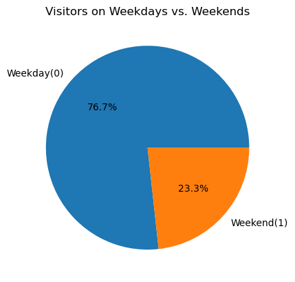

```python
#draw a pie chart to show df['Weekend']
import matplotlib.pyplot as plt

# count the number of visitors who visited on weekends vs. weekdays
weekend_count = df['Weekend'].value_counts()

# create a pie chart
plt.pie(weekend_count, labels=['Weekday(0)', 'Weekend(1)'], autopct='%1.1f%%')
plt.title('Visitors on Weekdays vs. Weekends')
plt.show()
```

```python
df['Revenue'].mean()
```

```
0.15474452554744525
```

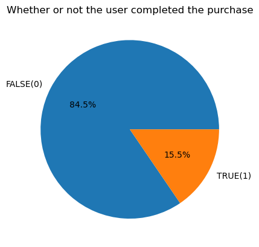

```python
#draw a pie chart to show df['Revenue']
import matplotlib.pyplot as plt

# count the number of visitors who visited on weekends vs. weekdays
Revenue_count = df['Revenue'].value_counts()

# create a pie chart
plt.pie(Revenue_count, labels=['FALSE(0)', 'TRUE(1)'], autopct='%1.1f%%')
plt.title('Whether or not the user completed the purchase')
plt.show()
```

## Kaplan-Meier analysis

Kaplan-Meier analysis can be used to calculate the probability of an event happening over time.

In order to perform survival analysis, we need to define the event of interest and the time variable.

For this dataset, we can define the event of interest as the time to conversion, or the time it takes for a website visitor to make a purchase on the site. We can use the Revenue column to identify whether a purchase was made or not.

The time variable would be the duration of the visit, which we can use the ProductRelated_Duration column to represent. This column represents the amount of time that the user spent on product-related pages, which could be a good proxy for the overall duration of the visit.

So we will define the event of interest as conversion (Revenue = TRUE) and the time variable as the duration of the visit (ProductRelated_Duration).

```python
# Define the event of interest and the time variable
T = df['ProductRelated_Duration']
E = df['Revenue']
```

```python
# Fit the Kaplan-Meier estimator
from lifelines import KaplanMeierFitter
kmf = KaplanMeierFitter()
kmf.fit(T, event_observed=E)
```

```
<lifelines.KaplanMeierFitter:"KM_estimate", fitted with 12330 total observations, 10422 right-censored observations>
```

```python
# Print the survival function
print(kmf.survival_function_)
```

```
              KM_estimate
timeline
0.000000         0.998946
0.500000         0.998946
1.000000         0.998946
2.333333         0.998946
2.666667         0.998946
...                   ...
24844.156200     0.115620
27009.859430     0.086715
29970.465970     0.086715
43171.233380     0.086715
63973.522230     0.086715

[9551 rows x 1 columns]
```

```python
# Confidence interval for the survival function
ci = kmf.confidence_interval_survival_function_
ci
```

|  | KM_estimate_lower_0.95 | KM_estimate_upper_0.95 |
| --- | --- | --- |
| 0.000000 | 0.998185 | 0.999388 |
| 0.500000 | 0.998185 | 0.999388 |
| 1.000000 | 0.998185 | 0.999388 |
| 2.333333 | 0.998185 | 0.999388 |
| 2.666667 | 0.998185 | 0.999388 |
| ... | ... | ... |
| 24844.156200 | 0.071283 | 0.171638 |
| 27009.859430 | 0.037816 | 0.161132 |
| 29970.465970 | 0.037816 | 0.161132 |
| 43171.233380 | 0.037816 | 0.161132 |
| 63973.522230 | 0.037816 | 0.161132 |

9551 rows × 2 columns

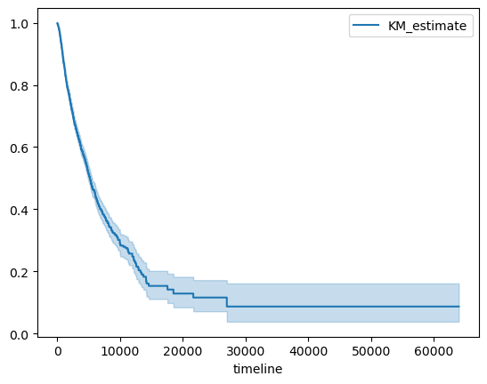

```python
# Create a plot
kmf.plot(ci_show=True)
```

### Conclusion

When customers browse the product page for more than 20,000 seconds, we can basically determine whether they will buy or not.

```python
# instantiate the class to create an object
kmf1 = KaplanMeierFitter()
```

```python
# Two Cohorts are compared. Cohort 1 Weekend = TRUE, and Cohort 2 Weekend = FALSE
groups = df['Weekend']

i1 = (groups == 1.0)      ## group i1 , having the pandas series for the 1st cohort
i2 = (groups == 0.0)     ## group i2 , having the pandas series for the 2nd cohort
```

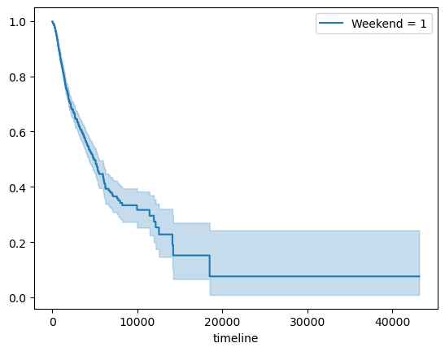

```python
T = df['ProductRelated_Duration']
E = df['Revenue']

## fit the model for 1st cohort
kmf1 = KaplanMeierFitter()  ## instantiate the class to create an object
kmf1.fit(T[i1], E[i1], label= 'Weekend = 1')
kmf1.plot()
```

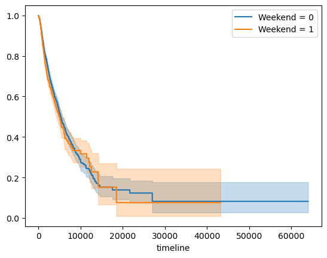

```python
## fit the model for 2nd cohort
kmf2 = KaplanMeierFitter()
kmf2.fit(T[i2], E[i2], label='Weekend = 0')

kmf2.plot()
kmf1.plot()
```

```python
# Helper function for printing out Log-rank test results
from lifelines.statistics import pairwise_logrank_test
def print_logrank(col):
    log_rank = pairwise_logrank_test(df['ProductRelated_Duration'], df[col], df['Revenue'])
    return log_rank.summary
```

```python
print_logrank('Weekend')
```

|  |  | test_statistic | p | -log2(p) |
| --- | --- | --- | --- | --- |
| 0 | 1 | 6.035081 | 0.014024 | 6.155927 |

### Conclusion

p < 0.05, we can reject the null hypothesis that the two groups are statistically equivalent. This means that we can conclude that there is a statistically significant difference between the groups being compared, and we should reject the possibility that any observed difference is due to random chance.

On weekends, customers spend less time on product pages to make purchases.

## Cox Regression

Proportional hazards regression, also known as Cox regression, is a type of regression analysis used to model the relationship between the survival time of an event and one or more predictor variables, also known as covariates.

The key assumption of Cox regression is that the hazard function, which describes the rate of occurrence of the event at any given time, is proportional over time for different levels of the covariates. This means that the effect of the covariates on the hazard rate is constant over time.

In other words, the hazard ratio (HR) between two groups with different levels of a covariate is constant over time. For example, if the HR between two groups with different levels of a covariate is 2, then the hazard rate of the group with the higher level of the covariate is twice that of the group with the lower level of the covariate, regardless of the time elapsed.

Cox Regression can help us to find the predictive variables and the event. There are lots of variables in the dataset, we can use the method to find the most relevant factors to purchasing.

The dataset has the property of time. It also includes event variables. It works for the requirements of Cox Regression.

```python
from lifelines import CoxPHFitter
```

```python
# Define the covariates for the regression
covariates = ['Administrative', 'Administrative_Duration', 'Informational', 'Informational_Duration',
              'ProductRelated', 'BounceRates', 'ExitRates', 'PageValues', 'SpecialDay',
              'OperatingSystems', 'Browser', 'Region', 'TrafficType', 'Weekend',
              'Month_Dec', 'Month_Feb', 'Month_Jul', 'Month_June', 'Month_Mar', 'Month_May',
              'Month_Nov', 'Month_Oct', 'Month_Sep',
              'VisitorType_Other', 'VisitorType_Returning_Visitor','ProductRelated_Duration','Revenue']
```

```python
# Fit the Cox proportional hazards model
cph = CoxPHFitter()
cph.fit(df[covariates], duration_col='ProductRelated_Duration', event_col='Revenue')
```

```
<lifelines.CoxPHFitter: fitted with 12330 total observations, 10422 right-censored observations>
```

```python
# access the individual results using cph.summary
cph.print_summary()
```

| model | lifelines.CoxPHFitter |
| --- | --- |
| duration col | 'ProductRelated_Duration' |
| event col | 'Revenue' |
| baseline estimation | breslow |
| number of observations | 12330 |
| number of events observed | 1908 |
| partial log-likelihood | -14004.29 |
| time fit was run | 2023-04-15 17:57:26 UTC |

|  | coef | exp(coef) | se(coef) | coef lower 95% | coef upper 95% | exp(coef) lower 95% | exp(coef) upper 95% | cmp to | z | p | -log2(p) |
| --- | --- | --- | --- | --- | --- | --- | --- | --- | --- | --- | --- |
| Administrative | 0.03 | 1.03 | 0.01 | 0.01 | 0.04 | 1.01 | 1.05 | 0.00 | 3.42 | <0.005 | 10.66 |
| Administrative_Duration | -0.00 | 1.00 | 0.00 | -0.00 | -0.00 | 1.00 | 1.00 | 0.00 | -4.72 | <0.005 | 18.72 |
| Informational | 0.01 | 1.01 | 0.02 | -0.03 | 0.05 | 0.97 | 1.05 | 0.00 | 0.29 | 0.77 | 0.38 |
| Informational_Duration | -0.00 | 1.00 | 0.00 | -0.00 | -0.00 | 1.00 | 1.00 | 0.00 | -2.56 | 0.01 | 6.56 |
| ProductRelated | -0.02 | 0.98 | 0.00 | -0.03 | -0.02 | 0.98 | 0.98 | 0.00 | -26.40 | <0.005 | 507.66 |
| BounceRates | -13.93 | 0.00 | 3.92 | -21.61 | -6.24 | 0.00 | 0.00 | 0.00 | -3.55 | <0.005 | 11.34 |
| ExitRates | -8.01 | 0.00 | 2.40 | -12.72 | -3.30 | 0.00 | 0.04 | 0.00 | -3.34 | <0.005 | 10.20 |
| PageValues | 0.01 | 1.01 | 0.00 | 0.01 | 0.01 | 1.01 | 1.01 | 0.00 | 29.31 | <0.005 | 625.06 |
| SpecialDay | -0.37 | 0.69 | 0.20 | -0.77 | 0.02 | 0.46 | 1.02 | 0.00 | -1.84 | 0.07 | 3.92 |
| OperatingSystems | -0.13 | 0.87 | 0.03 | -0.20 | -0.07 | 0.82 | 0.93 | 0.00 | -4.24 | <0.005 | 15.44 |
| Browser | 0.02 | 1.02 | 0.01 | -0.01 | 0.05 | 0.99 | 1.05 | 0.00 | 1.31 | 0.19 | 2.39 |
| Region | -0.03 | 0.97 | 0.01 | -0.05 | -0.01 | 0.95 | 0.99 | 0.00 | -3.42 | <0.005 | 10.64 |
| TrafficType | 0.01 | 1.01 | 0.01 | -0.01 | 0.02 | 0.99 | 1.02 | 0.00 | 0.92 | 0.36 | 1.48 |
| Weekend | 0.13 | 1.13 | 0.05 | 0.02 | 0.23 | 1.02 | 1.26 | 0.00 | 2.37 | 0.02 | 5.80 |
| Month_Dec | -0.58 | 0.56 | 0.14 | -0.85 | -0.31 | 0.43 | 0.73 | 0.00 | -4.27 | <0.005 | 15.63 |
| Month_Feb | -1.66 | 0.19 | 0.59 | -2.82 | -0.51 | 0.06 | 0.60 | 0.00 | -2.82 | <0.005 | 7.69 |
| Month_Jul | 0.14 | 1.14 | 0.17 | -0.20 | 0.47 | 0.82 | 1.60 | 0.00 | 0.80 | 0.43 | 1.23 |
| Month_June | -0.55 | 0.58 | 0.22 | -0.99 | -0.11 | 0.37 | 0.89 | 0.00 | -2.47 | 0.01 | 6.22 |
| Month_Mar | -0.66 | 0.52 | 0.14 | -0.93 | -0.39 | 0.39 | 0.68 | 0.00 | -4.80 | <0.005 | 19.29 |
| Month_May | -0.47 | 0.62 | 0.13 | -0.73 | -0.22 | 0.48 | 0.81 | 0.00 | -3.61 | <0.005 | 11.69 |
| Month_Nov | 0.00 | 1.00 | 0.12 | -0.24 | 0.24 | 0.79 | 1.28 | 0.00 | 0.03 | 0.98 | 0.03 |
| Month_Oct | -0.13 | 0.88 | 0.15 | -0.43 | 0.16 | 0.65 | 1.18 | 0.00 | -0.88 | 0.38 | 1.40 |
| Month_Sep | -0.12 | 0.89 | 0.16 | -0.43 | 0.19 | 0.65 | 1.21 | 0.00 | -0.75 | 0.45 | 1.15 |
| VisitorType_Other | -0.01 | 0.99 | 0.34 | -0.67 | 0.66 | 0.51 | 1.93 | 0.00 | -0.02 | 0.99 | 0.02 |
| VisitorType_Returning_Visitor | -0.59 | 0.55 | 0.06 | -0.72 | -0.47 | 0.49 | 0.63 | 0.00 | -9.21 | <0.005 | 64.79 |

| Concordance | 0.84 |
| --- | --- |
| Partial AIC | 28058.59 |
| log-likelihood ratio test | 2410.32 on 25 df |
| -log2(p) of ll-ratio test | inf |

### Conclusion

The purpose of this model is to predict the probability that a website visitor will make a purchase on the site, based on various features or characteristics of the visitor's session.

Each independent variable represents a feature of the visitor's session, such as the number of administrative pages visited, the duration of the visitor's session, the bounce rate (i.e., the percentage of visitors who leave the site after viewing only one page), the page value (i.e., the average value of the pages viewed by the visitor), the special day (i.e., whether the visitor's session occurred on a special day such as a holiday), and so on.

The standard error provides an estimate of the variability in the coefficient estimate, and the confidence intervals provide a range of values within which the true value of the coefficient is likely to fall. The z-score and p-value tell us whether the coefficient estimate is statistically significant (i.e., whether it is unlikely to have occurred by chance alone). If the p-value is less than a predetermined threshold (e.g., 0.05), we reject the null hypothesis that the coefficient is equal to zero (i.e., that the feature has no effect on the log odds of making a purchase) and conclude that the feature has a statistically significant effect on the outcome.

We should delete the variables which have 0 coefficient or p-value > 0.05.

```python
# Define the covariates for the regression
covariates = ['Administrative',
              'ProductRelated', 'BounceRates', 'ExitRates', 'PageValues',
              'OperatingSystems', 'Region',  'Weekend',
              'Month_Dec', 'Month_Feb', 'Month_June', 'Month_Mar', 'Month_May',
              'VisitorType_Returning_Visitor','ProductRelated_Duration','Revenue']
```

```python
# Fit the Cox proportional hazards model
cph = CoxPHFitter()
cph.fit(df[covariates], duration_col='ProductRelated_Duration', event_col='Revenue')
```

```
<lifelines.CoxPHFitter: fitted with 12330 total observations, 10422 right-censored observations>
```

```python
# access the individual results using cph.summary
cph.print_summary()
```

| model | lifelines.CoxPHFitter |
| --- | --- |
| duration col | 'ProductRelated_Duration' |
| event col | 'Revenue' |
| baseline estimation | breslow |
| number of observations | 12330 |
| number of events observed | 1908 |
| partial log-likelihood | -14028.69 |
| time fit was run | 2023-04-15 17:57:30 UTC |

|  | coef | exp(coef) | se(coef) | coef lower 95% | coef upper 95% | exp(coef) lower 95% | exp(coef) upper 95% | cmp to | z | p | -log2(p) |
| --- | --- | --- | --- | --- | --- | --- | --- | --- | --- | --- | --- |
| Administrative | 0.00 | 1.00 | 0.01 | -0.01 | 0.01 | 0.99 | 1.01 | 0.00 | 0.00 | 1.00 | 0.00 |
| ProductRelated | -0.02 | 0.98 | 0.00 | -0.02 | -0.02 | 0.98 | 0.98 | 0.00 | -26.72 | <0.005 | 520.01 |
| BounceRates | -14.77 | 0.00 | 3.90 | -22.42 | -7.12 | 0.00 | 0.00 | 0.00 | -3.78 | <0.005 | 12.66 |
| ExitRates | -7.68 | 0.00 | 2.38 | -12.34 | -3.01 | 0.00 | 0.05 | 0.00 | -3.22 | <0.005 | 9.63 |
| PageValues | 0.01 | 1.01 | 0.00 | 0.01 | 0.01 | 1.01 | 1.01 | 0.00 | 29.62 | <0.005 | 638.06 |
| OperatingSystems | -0.12 | 0.89 | 0.03 | -0.17 | -0.07 | 0.84 | 0.94 | 0.00 | -4.39 | <0.005 | 16.43 |
| Region | -0.03 | 0.97 | 0.01 | -0.05 | -0.01 | 0.95 | 0.99 | 0.00 | -3.40 | <0.005 | 10.53 |
| Weekend | 0.14 | 1.15 | 0.05 | 0.04 | 0.25 | 1.04 | 1.28 | 0.00 | 2.71 | 0.01 | 7.20 |
| Month_Dec | -0.57 | 0.56 | 0.08 | -0.72 | -0.42 | 0.49 | 0.65 | 0.00 | -7.58 | <0.005 | 44.74 |
| Month_Feb | -1.70 | 0.18 | 0.58 | -2.84 | -0.57 | 0.06 | 0.57 | 0.00 | -2.94 | <0.005 | 8.27 |
| Month_June | -0.52 | 0.60 | 0.19 | -0.90 | -0.14 | 0.41 | 0.87 | 0.00 | -2.67 | 0.01 | 7.04 |
| Month_Mar | -0.67 | 0.51 | 0.08 | -0.82 | -0.51 | 0.44 | 0.60 | 0.00 | -8.34 | <0.005 | 53.63 |
| Month_May | -0.51 | 0.60 | 0.06 | -0.63 | -0.39 | 0.53 | 0.68 | 0.00 | -8.25 | <0.005 | 52.51 |
| VisitorType_Returning_Visitor | -0.59 | 0.55 | 0.06 | -0.72 | -0.47 | 0.49 | 0.63 | 0.00 | -9.28 | <0.005 | 65.73 |

| Concordance | 0.84 |
| --- | --- |
| Partial AIC | 28085.39 |
| log-likelihood ratio test | 2361.52 on 14 df |
| -log2(p) of ll-ratio test | inf |

### Conclusion

ProductRelated, BounceRates, ExitRates, OperatingSystems, Region, Month_Dec, Month_Feb, Month_June, Month_Mar, Month_May, VisitorType_Returning_Visitor have negative impact

PageValues, Weekend have positive impact

## OLS model

```python
df.dtypes
```

```
Administrative                     int64
Administrative_Duration          float64
Informational                      int64
Informational_Duration           float64
ProductRelated                     int64
ProductRelated_Duration          float64
BounceRates                      float64
ExitRates                        float64
PageValues                       float64
SpecialDay                       float64
OperatingSystems                   int64
Browser                            int64
Region                             int64
TrafficType                        int64
Weekend                            uint8
Revenue                            uint8
Month_Aug                          uint8
Month_Dec                          uint8
Month_Feb                          uint8
Month_Jul                          uint8
Month_June                         uint8
Month_Mar                          uint8
Month_May                          uint8
Month_Nov                          uint8
Month_Oct                          uint8
Month_Sep                          uint8
VisitorType_New_Visitor            uint8
VisitorType_Other                  uint8
VisitorType_Returning_Visitor      uint8
dtype: object
```

```python
Y = df['Revenue']
```

```python
X = df[[      'Administrative', 'Administrative_Duration', 'Informational', 'Informational_Duration',
              'ProductRelated','ProductRelated_Duration', 'BounceRates', 'ExitRates', 'PageValues', 'SpecialDay',
              'OperatingSystems', 'Browser', 'Region', 'TrafficType', 'Weekend', 'Month_Aug',
              'Month_Dec', 'Month_Feb', 'Month_Jul', 'Month_June', 'Month_Mar', 'Month_May',
              'Month_Nov', 'Month_Oct', 'Month_Sep', 'VisitorType_New_Visitor',
              'VisitorType_Other', 'VisitorType_Returning_Visitor','ProductRelated_Duration']]
X.dtypes
```

```
Administrative                     int64
Administrative_Duration          float64
Informational                      int64
Informational_Duration           float64
ProductRelated                     int64
ProductRelated_Duration          float64
BounceRates                      float64
ExitRates                        float64
PageValues                       float64
SpecialDay                       float64
OperatingSystems                   int64
Browser                            int64
Region                             int64
TrafficType                        int64
Weekend                            uint8
Month_Aug                          uint8
Month_Dec                          uint8
Month_Feb                          uint8
Month_Jul                          uint8
Month_June                         uint8
Month_Mar                          uint8
Month_May                          uint8
Month_Nov                          uint8
Month_Oct                          uint8
Month_Sep                          uint8
VisitorType_New_Visitor            uint8
VisitorType_Other                  uint8
VisitorType_Returning_Visitor      uint8
ProductRelated_Duration          float64
dtype: object
```

```python
X = sm.add_constant(X)
model1 = sm.OLS(Y, X).fit()
model1.summary()
```

OLS Regression Results

| Dep. Variable: | Revenue | R-squared: | 0.288 |
| --- | --- | --- | --- |
| Model: | OLS | Adj. R-squared: | 0.287 |
| Method: | Least Squares | F-statistic: | 191.5 |
| Date: | Sat, 15 Apr 2023 | Prob (F-statistic): | 0.00 |
| Time: | 14:10:19 | Log-Likelihood: | -2859.9 |
| No. Observations: | 12330 | AIC: | 5774. |
| Df Residuals: | 12303 | BIC: | 5974. |
| Df Model: | 26 |  |  |
| Covariance Type: | nonrobust |  |  |

|  | coef | std err | t | P>\|t\| | [0.025 | 0.975] |
| --- | --- | --- | --- | --- | --- | --- |
| const | 0.0845 | 0.013 | 6.377 | 0.000 | 0.059 | 0.111 |
| Administrative | 0.0019 | 0.001 | 1.608 | 0.108 | -0.000 | 0.004 |
| Administrative_Duration | -1.605e-05 | 2.02e-05 | -0.793 | 0.428 | -5.57e-05 | 2.36e-05 |
| Informational | 0.0034 | 0.003 | 1.150 | 0.250 | -0.002 | 0.009 |
| Informational_Duration | 1.523e-05 | 2.53e-05 | 0.601 | 0.548 | -3.44e-05 | 6.49e-05 |
| ProductRelated | 0.0002 | 0.000 | 1.766 | 0.077 | -2.55e-05 | 0.000 |
| ProductRelated_Duration | 5.148e-06 | 1.5e-06 | 3.434 | 0.001 | 2.21e-06 | 8.09e-06 |
| BounceRates | 0.4768 | 0.144 | 3.318 | 0.001 | 0.195 | 0.759 |
| ExitRates | -1.0163 | 0.152 | -6.707 | 0.000 | -1.313 | -0.719 |
| PageValues | 0.0089 | 0.000 | 58.683 | 0.000 | 0.009 | 0.009 |
| SpecialDay | -0.0165 | 0.016 | -1.033 | 0.301 | -0.048 | 0.015 |
| OperatingSystems | -0.0081 | 0.003 | -2.470 | 0.014 | -0.014 | -0.002 |
| Browser | 0.0039 | 0.002 | 2.268 | 0.023 | 0.001 | 0.007 |
| Region | -0.0018 | 0.001 | -1.586 | 0.113 | -0.004 | 0.000 |
| TrafficType | -0.0001 | 0.001 | -0.201 | 0.841 | -0.002 | 0.001 |
| Weekend | 0.0078 | 0.007 | 1.193 | 0.233 | -0.005 | 0.021 |
| Month_Aug | 0.0243 | 0.014 | 1.747 | 0.081 | -0.003 | 0.052 |
| Month_Dec | -0.0256 | 0.008 | -3.261 | 0.001 | -0.041 | -0.010 |
| Month_Feb | -0.0360 | 0.021 | -1.708 | 0.088 | -0.077 | 0.005 |
| Month_Jul | 0.0268 | 0.014 | 1.921 | 0.055 | -0.001 | 0.054 |
| Month_June | -0.0085 | 0.017 | -0.507 | 0.612 | -0.042 | 0.024 |
| Month_Mar | -0.0144 | 0.008 | -1.882 | 0.060 | -0.029 | 0.001 |
| Month_May | -0.0158 | 0.007 | -2.271 | 0.023 | -0.029 | -0.002 |
| Month_Nov | 0.0868 | 0.007 | 12.991 | 0.000 | 0.074 | 0.100 |
| Month_Oct | 0.0276 | 0.013 | 2.191 | 0.028 | 0.003 | 0.052 |
| Month_Sep | 0.0193 | 0.014 | 1.402 | 0.161 | -0.008 | 0.046 |
| VisitorType_New_Visitor | 0.0671 | 0.011 | 6.323 | 0.000 | 0.046 | 0.088 |
| VisitorType_Other | -0.0015 | 0.029 | -0.052 | 0.959 | -0.058 | 0.055 |
| VisitorType_Returning_Visitor | 0.0190 | 0.010 | 1.968 | 0.049 | 7.72e-05 | 0.038 |
| ProductRelated_Duration | 5.148e-06 | 1.5e-06 | 3.434 | 0.001 | 2.21e-06 | 8.09e-06 |

| Omnibus: | 3066.981 | Durbin-Watson: | 2.007 |
| --- | --- | --- | --- |
| Prob(Omnibus): | 0.000 | Jarque-Bera (JB): | 10197.191 |
| Skew: | 1.248 | Prob(JB): | 0.00 |
| Kurtosis: | 6.690 | Cond. No. | 1.47e+16 |

Notes:  
[1] Standard Errors assume that the covariance matrix of the errors is correctly specified.  
[2] The smallest eigenvalue is 5.82e-22. This might indicate that there are  
strong multicollinearity problems or that the design matrix is singular.

```python
X = df[[      'ProductRelated_Duration', 'BounceRates', 'ExitRates', 'PageValues',
              'OperatingSystems', 'Browser', 'Region', 'Weekend', 'Month_Aug',
              'Month_Dec', 'Month_Jul', 'Month_June', 'Month_Mar', 'Month_May',
              'Month_Oct', 'Month_Sep', 'VisitorType_New_Visitor',
              'VisitorType_Returning_Visitor','ProductRelated_Duration']]
X = sm.add_constant(X)
model2 = sm.OLS(Y, X).fit()
model2.summary()
```

OLS Regression Results

| Dep. Variable: | Revenue | R-squared: | 0.286 |
| --- | --- | --- | --- |
| Model: | OLS | Adj. R-squared: | 0.284 |
| Method: | Least Squares | F-statistic: | 273.3 |
| Date: | Sat, 15 Apr 2023 | Prob (F-statistic): | 0.00 |
| Time: | 14:12:24 | Log-Likelihood: | -2882.5 |
| No. Observations: | 12330 | AIC: | 5803. |
| Df Residuals: | 12311 | BIC: | 5944. |
| Df Model: | 18 |  |  |
| Covariance Type: | nonrobust |  |  |

|  | coef | std err | t | P>\|t\| | [0.025 | 0.975] |
| --- | --- | --- | --- | --- | --- | --- |
| const | 0.1701 | 0.042 | 4.084 | 0.000 | 0.088 | 0.252 |
| ProductRelated_Duration | 8.448e-06 | 7.72e-07 | 10.946 | 0.000 | 6.94e-06 | 9.96e-06 |
| BounceRates | 0.5669 | 0.142 | 3.999 | 0.000 | 0.289 | 0.845 |
| ExitRates | -1.1711 | 0.146 | -7.995 | 0.000 | -1.458 | -0.884 |
| PageValues | 0.0090 | 0.000 | 58.904 | 0.000 | 0.009 | 0.009 |
| OperatingSystems | -0.0078 | 0.003 | -2.406 | 0.016 | -0.014 | -0.001 |
| Browser | 0.0037 | 0.002 | 2.142 | 0.032 | 0.000 | 0.007 |
| Region | -0.0018 | 0.001 | -1.559 | 0.119 | -0.004 | 0.000 |
| Weekend | 0.0092 | 0.007 | 1.406 | 0.160 | -0.004 | 0.022 |
| Month_Aug | -0.0531 | 0.016 | -3.385 | 0.001 | -0.084 | -0.022 |
| Month_Dec | -0.1055 | 0.009 | -11.391 | 0.000 | -0.124 | -0.087 |
| Month_Jul | -0.0510 | 0.016 | -3.242 | 0.001 | -0.082 | -0.020 |
| Month_June | -0.0855 | 0.019 | -4.527 | 0.000 | -0.122 | -0.048 |
| Month_Mar | -0.0945 | 0.009 | -10.538 | 0.000 | -0.112 | -0.077 |
| Month_May | -0.0988 | 0.008 | -12.893 | 0.000 | -0.114 | -0.084 |
| Month_Oct | -0.0503 | 0.014 | -3.544 | 0.000 | -0.078 | -0.022 |
| Month_Sep | -0.0594 | 0.015 | -3.834 | 0.000 | -0.090 | -0.029 |
| VisitorType_New_Visitor | 0.0688 | 0.038 | 1.814 | 0.070 | -0.006 | 0.143 |
| VisitorType_Returning_Visitor | 0.0209 | 0.037 | 0.561 | 0.575 | -0.052 | 0.094 |
| ProductRelated_Duration | 8.448e-06 | 7.72e-07 | 10.946 | 0.000 | 6.94e-06 | 9.96e-06 |

| Omnibus: | 3123.943 | Durbin-Watson: | 2.001 |
| --- | --- | --- | --- |
| Prob(Omnibus): | 0.000 | Jarque-Bera (JB): | 10473.238 |
| Skew: | 1.269 | Prob(JB): | 0.00 |
| Kurtosis: | 6.735 | Cond. No. | 8.66e+15 |

Notes:  
[1] Standard Errors assume that the covariance matrix of the errors is correctly specified.  
[2] The smallest eigenvalue is 1.67e-21. This might indicate that there are  
strong multicollinearity problems or that the design matrix is singular.

### Conclusion

Accuracy is low, but it is certain that some variables are significant because p-value < 0.05.

# Implications

It is feasible to build a machine learning model to predict purchase intention in an e-commerce environment.

# Limitations

## For now, we assume that product related page may be the most relevant factor. And there is doubt that whether administration duration has a significant impact on the probability of an event occurring. But these need to be proven in the analysis process. We kind of worry there may be a limitation of this dataset. It does provide the duration time and customers’ browsing time for us. But all these variables are generated from the website angle. We don’t get the information on customers’ profiles. What if the most important factor is the characteristics of customers rather than the website’s design? This is an unknown question to us.

## Data for January and April are missing from the table, and our conclusions can only be drawn for the other months.